# Analysis of Stowasser et al. 2006 data

Here we demonstrate the validity of our methods by re-analysing the experimental dataset of Stowasser et al. The original paper investigated the evolution of stable isotope (C/N) and fatty acid signatures for squid fed either fish, crustacean or mixed diets, as well as switched diet regimes. Our specific aim here is to estiamte diet proportions of mixed diet individuals, and to show the advantage of using both markers in concert over using a single marker for diet analysis.

We begin the analysis using just SI. Hussey et al 2014 (Ecology Letters Volume 17, Issue 2, pages 239–250, February 2014), following earlier analyses by Caut et al and others, showed that discimintation is prey N dependent, and used a meta-analytic model to estiamte discrimination coefficients.

We initially estiamte prey specific discimination in stable isotopes following Hussey et al 2014, and develop analogous methods for fatty acid signatures. Discrimination is estiamted for both types of marker from animals that were fed on diets containing a single prey type (Fish or Crustaceans).

## Stable Isotope analysis

We first read in the data tables for SI:

```r
library(fastinR, warn.conflicts = F)
require(dplyr)

prey.table <- read.csv("Prey_SI.csv", header = T, stringsAsFactors = F)
pred.table <- read.csv("Predator_SI.csv", header = T, stringsAsFactors = F)

# use only mixed feed individuals for analysis - using dplyr
pred.table <- pred.table %.% filter(Feed == "Mixed") %.% select(X_13C, X_15N)
```

We estimate discrimintation coefficients (also termed fractionation or conversion for SI and FA, respectively) using Bayesian models. The analysis is done in a separate file (Discrim.Analysis.R) and produces files discr.means.csv/discr.var.csv for SI, and corresponding cc_FA.csv and cc_FA_var.csv for FA.The estiamtion isn't trivial, so we just pass over it here. We instead proceed with the analysis by adding the necessary items for the final analysis to the workspace, using the add_SI function in fastin-R. This function just adds the data, and puts it into a specific format.

```r
squid.data <- add_SI(SI.predators = pred.table, SI.preys = prey.table, Frac.Coeffs.mean = "discr.means.csv",
    Frac.Coeffs.var = "discr.var.csv")
```

This is all we need for a first analysis using SI data. We can now visualize the data on an Non-Metric Dimensional Scaling plot like so:

```
## ... procrustes: rmse 0.002492  max resid 0.007928
## *** Solution reached
```

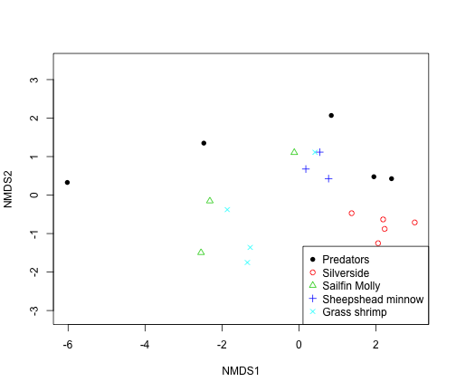

```r
dataplot(squid.data)
```

SIs seem to provide some separation among diet items, even within fish, but there is still strong overlap. One way to find out if the analysis of SI alone yields anything interpretable.

The run_MCMC function is the main workhorse for any type of analysis, it uses methods dispatch (=different models) based on function arguments and data types. Notice that the `Data.Type` argument is set to `'Stable.Isotopes'` and the `Analysis.Type` is `'Population.proportions'`. Lets not worry about the rest for now.

```r
Squid.SI.run1 <- run_MCMC(datas = squid.data, nIter = 10000, nBurnin = 1000,
    nChains = 3, nThin = 10, Data.Type = "Stable.Isotopes", Analysis.Type = "Population.proportions",
    Rnot_SI = 0.01, plott = F, spawn = F)
```

```
##    Graph Size: 114
##
##
##
##  proceeding to burn-in phase
##
##  sampling from parameter distributions
```

Plotting the MCMC is the easiest way to ensure that the sampler is mixing - meaning that the Markov chain explores the posterior distribution of each parameter efficiently.

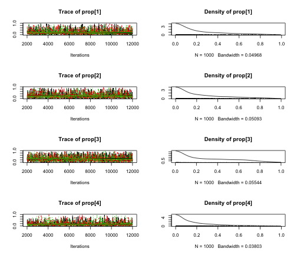

```r
MCMCplot(Squid.SI.run1)
```

This looks rather uninformative, let's see if this is due to chains not running long enough. The `diags` function gives more information, it dispalys two types of diagnostics (from coda package):

```r
diags(Squid.SI.run1)
```

```
##
##
## #################################
## Raftery-Lewis diagnostics
## #################################
##
## [[1]]
##
## Quantile (q) = 0.025
## Accuracy (r) = +/- 0.01
## Probability (s) = 0.95
##
##          Burn-in  Total Lower bound  Dependence
##          (M)      (N)   (Nmin)       factor (I)
##  prop[1] 20       9690  937          10.3
##  prop[2] 30       10110 937          10.8
##  prop[3] 20       9690  937          10.3
##  prop[4] 30       10530 937          11.2
##
##
## [[2]]
##
## Quantile (q) = 0.025
## Accuracy (r) = +/- 0.01
## Probability (s) = 0.95
##
##          Burn-in  Total Lower bound  Dependence
##          (M)      (N)   (Nmin)       factor (I)
##  prop[1] 40       12430 937          13.30
##  prop[2] 20       8930  937           9.53
##  prop[3] 30       11430 937          12.20
##  prop[4] 20       8930  937           9.53
##
##
## [[3]]
##
## Quantile (q) = 0.025
## Accuracy (r) = +/- 0.01
## Probability (s) = 0.95
##
```

[output cut: 20 more lines]

```
##
##         Point est. Upper C.I.
## prop[1]          1       1.01
## prop[2]          1       1.01
## prop[3]          1       1.01
## prop[4]          1       1.00
##
## Multivariate psrf
##
## 1
##
##  Both univariate upper C.I. and multivariate psrf
##  should be close to 1 if the chains converged
##
##
```

Lets run it again for a bit longer, this time using spawn=T, which 'spawns' invisible R processes that do the calculations

```r
Squid.SI.run2 <- run_MCMC(datas = squid.data, nIter = 1e+05, nBurnin = 10000,
    nChains = 3, nThin = 100, Data.Type = "Stable.Isotopes", Analysis.Type = "Population.proportions",
    Rnot_SI = 0.01, plott = F, spawn = T)

diags(Squid.SI.run2)
```

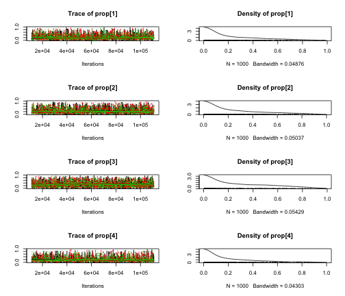

```r
MCMCplot(Squid.SI.run2)
```

Looks like that's about as good as it'll get, so let's look at a summary and produce a nicer plot for the outcome.

```r
summary(Squid.SI.run2)
```

```
## Using  as id variables
```

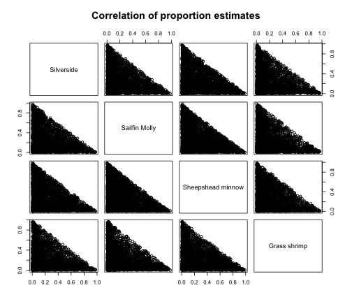

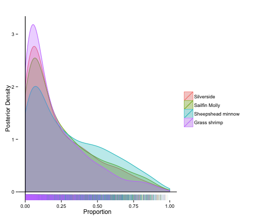

```r
plot(Squid.SI.run2, save = F)
```

Based on posterior medians, we'd say that Mixed diet treatment squid were mostly feeding on fish (at the level of the predator population), but there's considerable uncertainty. Does this reflect variability in the individual diets or uncertainty due to lack of signal in the data? We can set the `Analysis.Type` to `'Individual.proportions'` to see how individual diets vary and get a better idea.

```r
Squid.SI.run3 <- run_MCMC(datas = squid.data, nIter = 1e+06, nBurnin = 10000,
    nChains = 3, nThin = 1000, Data.Type = "Stable.Isotopes", Analysis.Type = "Individual.proportions",
    Rnot_SI = 10, plott = F, spawn = T)

diags(Squid.SI.run3)
```

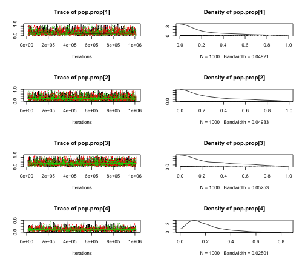

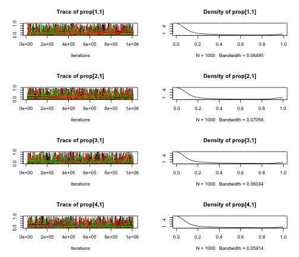

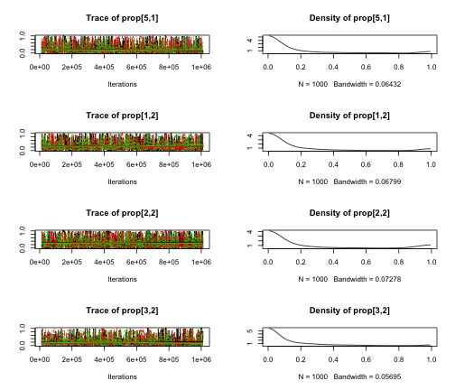

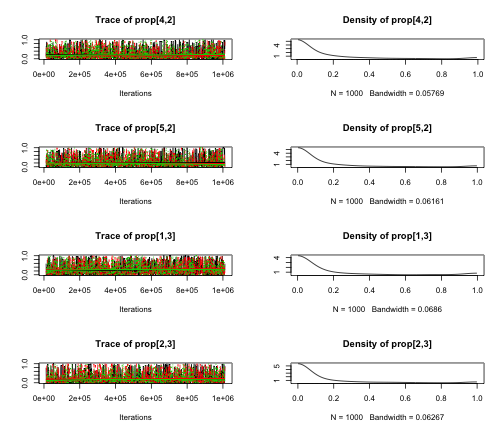

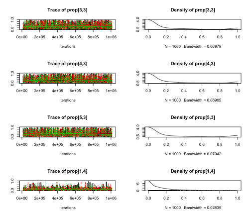

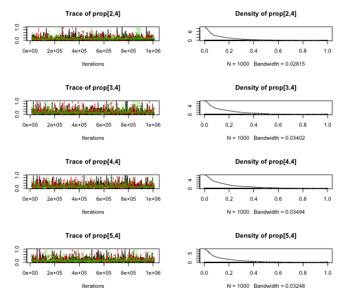

```r
MCMCplot(Squid.SI.run3)
```

```r
summary(Squid.SI.run3)
```

```
## Using  as id variables
```

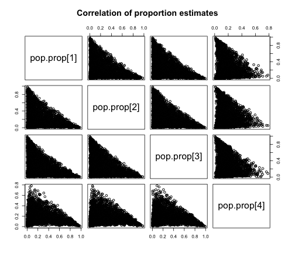

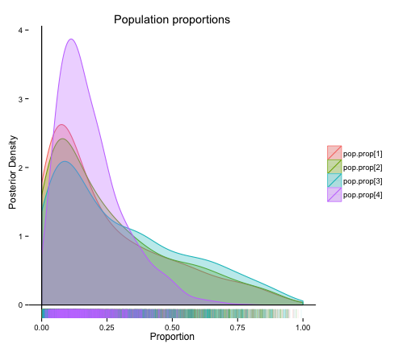

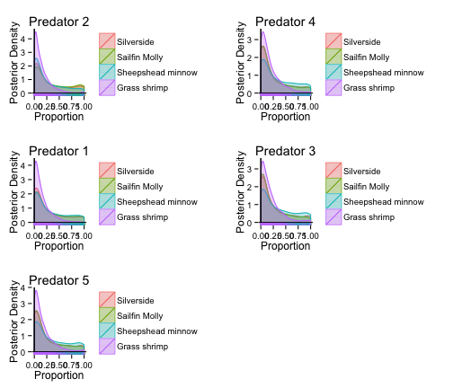

```r
plot(Squid.SI.run3, save = F)
```

This still looks very uncertain, and we could play with Rnot to see if we can get a better prior that improves mixing and perhaps the estiamtes. I tried that allready, and it doesn't work, which means that the uncertainty in the SI analysis is irreducible.

Let's switch to fatty acids and see what that data can reveal independently of SIs.